# Homework 3–4

Vladimir Yashin

### Gibbs sampler (Ross, Exercise 10b)

The following returns a DF that contains points (with two coords) on a circle with radius `r` that no two points is closer to each other than `d`

```r
unif_circle <- function(threshold = 10000, r = 1, d = 0.1) {
    # dummy for DF that will contain the coordinates for points
    df <- data.frame(x1 = NA, x2 = NA)

    # counter for the num of times new suggested points were declined
    skipped <- 0
    # run while the number of rejections is lower than given threshold
    while (skipped < threshold) {
        # in order to present points on a circle, first, we sample two points
        # distributed uniformly then we choose only ones that are in the circle
        x1 <- runif(n = 1, min = -r, max = r)
        x2 <- runif(n = 1, min = -r, max = r)

        # boolen whether point w/ coordinates x1 and x2 lies on a disk
        in_circle <- sqrt(x1^2 + x2^2) <= r

        # if the point does lie on a dist
        if (in_circle) {
            # calculate the distances between each point and the suggested one
            neib_dist <- sqrt(abs(x1 - df$x1)^2 + abs(x2 - df$x2)^2)
            # calculate the num of points that is closer than d to the new point
            neib_numb <- sum(neib_dist < d, na.rm = TRUE)
            # boolean whether the suggested point has no points that is closer
            # than d to the new point or the suggested point is the first in DF
            no_neibor <- (neib_numb == 0) | is.na(neib_numb)

            # if the point does not have any neighbours
            if (no_neibor) {
                # add the suggested point to DF
                df <- rbind(df, c(x1, x2))
                # reset the counter
                skipped <- 0
            # if it already has a neighbouring point
            } else {
                # add to counter
                skipped <- skipped + 1
            }
        }
    }
    # reset the indexing (it is 2..n) --> 1..n
    df <- df[-1, ]
    rownames(df) <- NULL

    return(df)
}
```

The following code returns a DF that contains ‘sample_size’ points (with two coords) on a circle with radius `r` that no two points is closer to each other than `d` given initial set of points that is on the disk (`initial`)

```r
gibbs_sampler <- function(sample_size, r, initial) {
    # reassign initial set to some var
    df <- initial
    # number of elements in the set
    n <- nrow(initial)

    # dummy DF that we expect to be filled with sampled points
    sampled <- data.frame(x1 = NA, x2 = NA)
    # iterate until we sample the needed amount of points
    # (+ 1 because it already has one row with NA's which will be deleted)
    while (nrow(sampled) < sample_size + 1) {

        # a random unif value
        U <- runif(n = 1)
        # calculate 'I' which is the index that we exclude from
        idx <- as.integer((n - 1) * U) + 1

        # generate two coordinates for a suggested point on a disk w/ radius r
        x1 <- runif(n = 1, min = -r, max = r)
        x2 <- runif(n = 1, min = -r, max = r)

        # boolean weither the suggested point is on the disk
        in_circle <- sqrt(x1^2 + x2^2) <= r

        # if it is on the disk
        if (in_circle) {
            # the neibourhood of the point with 'idx' index in 'df'
            # the 'df' is rbinded with 'sampled' because the 'sampled' points
            # should not be within the neibourhood with other 'sampled' points
            nighbours <- rbind(df[-idx, ], sampled)

            # calculate all distances between the suggested point and all points
            # except the one that is in idx, i. e. I
            neib_dist <- sqrt(abs(x1 - nighbours$x1)^2 + abs(x2 - nighbours$x2)^2)
            # calculate the num of points that is closer than d to the new point
            neib_numb <- sum(neib_dist < d, na.rm = TRUE)
            # boolean whether the suggested point has no points that is closer
            # than d to the new point or the suggested point is the first in DF
            no_neibor <- (neib_numb == 0) | is.na(neib_numb)

            # if the point does not have any neighbours
            if (no_neibor) {
                # add the suggested point to sample df
                sampled <- rbind(sampled, c(x1, x2))
            }
        }
    }
    # Delets 1st row. The 'sampled' was initiated with one row that has two NAs
    sampled <- sampled[-1, ]
    # reset the indexing (it is 2..n) --> 1..n
    rownames(sampled) <- NULL
    return(sampled)
}
```

Before we start sampling we shall choose some parameters

```r
# the amount of declined points on initialization. The higher threshold
# the lower \beta = P[no two points are within d of each other]
threshold <- 10000
# the lowest distance between neighbours
d <- 1 / 10
# number of suggested points in the gibbs sampler
sam_size <- 20
```

Let’s make some sample using the parameters specified above from a rv that distributed uniformly on a disk

```r
# initializing
init <- unif_circle(threshold = threshold, d = d)
# sampling using this initialization
smpl <- gibbs_sampler(sample_size = sam_size, r = 1, initial = init)
```

Now, let’s plot the results

```r
# plots the initial points (red)
plot(init, pch = 20, cex = 0.7, asp = 1, col = rgb(1, 0, 0, alpha = 0.3),
     xlim = c(-1.2, 1.2), ylim = c(-1.2, 1.2))
# add the generated ones to the plot (blue)
points(smpl, pch = 20, cex = 0.7, asp = 1, col = rgb(0, 0, 1, alpha = 0.3))
```

```r
# also draw the neighourhoods for each point for initial set and gerenated
symbols(x = init$x1, y = init$x2, circles = rep(d / 2, nrow(init)),
        inches = F, add = T, fg = rgb(1, 0, 0, alpha = 0.3))
symbols(x = smpl$x1, y = smpl$x2, circles = rep(d / 2, nrow(smpl)),
        inches = F, add = T, fg = rgb(0, 0, 1, alpha = 0.3))
```

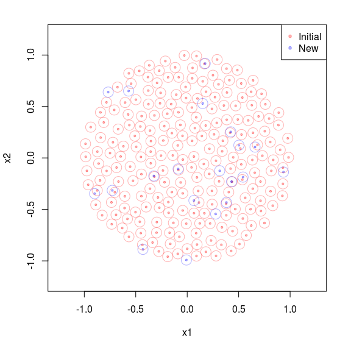

```r
# add legend
legend(x = 'topright', c('Initial', 'New'),
       col = c(rgb(1, 0, 0, alpha = 0.3), rgb(0, 0, 1, alpha = 0.3)),
       pch = c(20, 20), pt.bg = c('red', 'blue'))
```

But now let’s solve the Exercise 10 b.

```r
threshold <- 10000
# number of suggested points in the gibbs sampler
need <- 9
# the lowest distance between neighbours
d <- 1 / 8
```

```r
init <- unif_circle(threshold = threshold, r = 1, d = d)
smpl <- gibbs_sampler(sample_size = need, r = 1, initial = init)
```

```r
# first plotting the initial (red) points
plot(init, pch = 20, cex = 0.7, asp = 1, col = rgb(1, 0, 0, alpha = 0.3),
     xlim = c(-1.2, 1.2), ylim = c(-1.2, 1.2))
# add the generated ones (blue) on the disk. In case they haven't been changed
# two colors mix up to (red + blue = purple)
points(smpl, pch = 20, cex = 0.7, asp = 1, col = rgb(0, 0, 1, alpha = 0.3))
```

```r
# also draw the neighourhoods for each point for initial set and gerenated
symbols(x = init$x1, y = init$x2, circles = rep(d / 2, nrow(init)),
        inches = F, add = T, fg = rgb(1, 0, 0, alpha = 0.3))
symbols(x = smpl$x1, y = smpl$x2, circles = rep(d / 2, nrow(smpl)),
        inches = F, add = T, fg = rgb(0, 0, 1, alpha = 0.3))
```

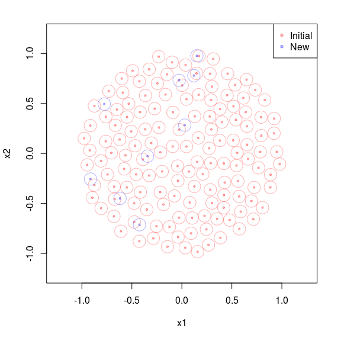

```r
# add legend
legend(x = 'topright', c('Initial', 'New'),
       col = c(rgb(1, 0, 0, alpha = 0.3), rgb(0, 0, 1, alpha = 0.3)),
       pch = c(20, 20),
       pt.bg = c('red', 'blue'))
```

```r
print(smpl)
```

| x1 | x2 |
| --- | --- |
| 0.15021739 | 0.97703382 |
| -0.02733350 | 0.73163895 |
| 0.02839214 | 0.28282314 |
| -0.34353983 | -0.02718107 |
| -0.91425125 | -0.25566133 |
| -0.61820349 | -0.44953075 |
| 0.12005908 | 0.77801823 |
| -0.42389675 | -0.71299228 |
| -0.77595713 | 0.49415006 |

### 8 queens on a chessboard

```r
# return a random chessbord given number of queens for arbitrary chessboard
# matrix with 1 -- queen, 0 -- empty
init_cond <- function(queens, dims = c(8, 8)) {

    # if the number of queens is higher than the number of cells, raise an error
    if (prod(dims) < queens) {
        stop(paste('I cannot locate', queens, 'queens on', prod(dims), 'cells'))
    }

    # assign the dimentions of a needed chessboard
    dim_x <- dims[1]
    dim_y <- dims[2]
    # reserve a place for each queen
    chessboard <- matrix(data = 0, nrow = dim_x, ncol = dim_y)

    # until the number of queens left is not zero implement
    while (queens > 0) {
        # choose randomly the row and column positions
        idx_x <- floor(dim_x * runif(1) + 1)
        idx_y <- floor(dim_y * runif(1) + 1)

        # if the choosen cell is empty place a queen on it & reduce the counter
        if (chessboard[idx_x, idx_y] == 0) {
            chessboard[idx_x, idx_y] <- 1
            queens <- queens - 1
        }
    }
    return(chessboard)
}
```

```r
# returns an error
init_cond(queens = 120, dims = c(8, 8)) # error
```

```
Error in init_cond(queens = 120, dims = c(8, 8)) :
  I cannot locate 120 queens on 64 cells
```

```r
init_cond(queens = 8, dims = c(8, 8))
```

```
     [,1] [,2] [,3] [,4] [,5] [,6] [,7] [,8]
[1,]    0    0    0    0    1    0    0    1
[2,]    0    0    0    0    0    0    0    0
[3,]    0    0    0    0    0    0    0    0
[4,]    0    0    1    0    0    0    0    0
[5,]    0    0    0    0    0    0    1    0
[6,]    0    0    1    0    0    1    1    0
[7,]    0    0    0    1    0    0    0    0
[8,]    0    0    0    0    0    0    0    0
```

```r
# also works with NxM dimention of a chessboard
init_cond(queens = 80, dims = c(9, 11))
```

```
      [,1] [,2] [,3] [,4] [,5] [,6] [,7] [,8] [,9] [,10] [,11]
 [1,]    1    1    1    1    1    1    1    1    0     1     1
 [2,]    1    1    1    0    0    1    1    1    1     1     1
 [3,]    1    1    1    0    1    1    1    0    1     0     1
 [4,]    1    1    1    1    1    1    1    0    1     0     0
 [5,]    1    1    0    1    1    1    0    1    1     0     1
 [6,]    1    1    1    0    1    1    1    0    1     1     1
 [7,]    1    1    1    1    0    1    1    1    0     0     1
 [8,]    1    1    0    1    1    1    1    1    1     1     1
 [9,]    1    1    1    1    1    1    1    1    0     1     1
```

```r
# returns a list of neighbours for a given a queen (its index) and a condition
neighbourhood <- function(queen_idx, condition) {

    dim_x <- nrow(condition)
    dim_y <- ncol(condition)
    # for the sake of comprehension assign indeces to two different values
    i <- queen_idx[1]
    j <- queen_idx[2]
    # list of indices for each queen
    queens <- which(condition == 1, arr.ind = TRUE)
    # reserve a list
    neighbours <- list()

    ## in this problem there are four types of neighbouring:
    # vertical (|) neighbours for Q(i, j) are Q(k, j)
    # for all k in [1, dim_x]
    domain <- seq(1, dim_x)

    # for each element in the domain
    for (d in 1:length(domain)) {
        k <- domain[d]

        # if the number of TRUEs is more than zero implement
        if (sum(queens[,1] == k & queens[,2] == j) > 0) {

            # to prevent: 'a queen is neighbour to herself'
            if (k != i) {
                # append the new index to the list
                neighbours <- c(neighbours, list(c(k, j)))
            }
        }
    }
    # horizontal (--) neighbours for Q(i, j) are Q(i, k)
    # for all k in [1, dim_y]
    domain <- seq(1, dim_y)

    # for each element in the domain
    for (d in 1:length(domain)) {
        k <- domain[d]

        # if the number of TRUEs is more than zero implement
        if (sum(queens[,1] == i & queens[,2] == k) > 0) {

            # to prevent: 'a queen is neighbour to herself'
            if (k != j) {
                # append the new index to the list
                neighbours <- c(neighbours, list(c(i, k)))
            }
        }
    }
    # diag (\) neighbours for Q(i, j) are Q(i+k, j+k)
    # for all k in [1-i, dim_x-i] intersect [1-j, dim_y-j]
    domain <- intersect(seq(1-i, dim_x-i), seq(1-j, dim_y-j))

    # for each element in the domain
    for (d in 1:length(domain)) {
        k <- domain[d]

        # if the number of TRUEs is more than zero implement
        if (sum(queens[,1] == (i + k) & queens[,2] == (j + k)) > 0) {

            # to prevent: 'a queen is neighbour to herself'
            if (k != 0) {
                # append the new index to the list
                neighbours <- c(neighbours, list(c((i + k), (j + k))))
            }
        }
    }
    # diag (/) neighbours for Q(i, j) are Q(i+k, j-k)
    # for all k in [1-i, dim_x-i] intersect [-dim_y+j, -1+j]
    domain <- intersect(seq(1-i, dim_x-i), seq(-dim_y+j, -1+j))

    # for each element in the domain
    for (d in 1:length(domain)) {
        k <- domain[d]

        # if the number of TRUEs is more than zero implement
        if (sum(queens[,1] == (i + k) & queens[,2] == (j - k)) > 0) {

            # to prevent: 'a queen is neighbour to herself'
            if (k != 0) {
                # append the new index to the list
                neighbours <- c(neighbours, list(c((i + k), (j - k))))
            }
        }
    }
    return(neighbours)
}
```

```r
set.seed(1)
# let's randomly place 5 queens on 4 by 3 chessboard
condition <- init_cond(queens = 5, c(4, 3))
print(condition)
```

```
     [,1] [,2] [,3]
[1,]    0    0    1
[2,]    0    1    0
[3,]    1    0    1
[4,]    0    1    0
```

```r
# for the queen that is placed on (1, 3) - see above - we have three neighbours
neighbourhood(queen_idx = c(1, 3), condition)
```

```
[[1]]
[1] 3 3

[[2]]
[1] 2 2

[[3]]
[1] 3 1
```

```r
# returns the number of queens that can be defeated by another given condition
energy <- function(condition) {

    dim_x <- nrow(condition)
    dim_y <- ncol(condition)
    # stays here! because it changes
    queens <- which(condition == 1, arr.ind = TRUE)
    # reserve a list
    reachable <- list()

    # for each queen add its neighbours (the queens that can defeat this one)
    for (i in 1:nrow(queens)) {
        # assign the index to another variable
        queen_idx <- queens[i, ]
        # remove the names that were assigned by 'which' function above
        names(queen_idx) <- NULL
        # find the neighbours for a queen
        neighbours <- neighbourhood(queen_idx, condition)
        # add the neighbours to the list
        reachable <- c(reachable, neighbours)
    }
    # remove duplicates: Q(1, 1) defeats Q(2, 2) and vice-versa
    reachable <- unique(reachable)

    return(length(reachable))
}
```

```r
set.seed(2)
# for the sake of example, let's create some state
condition <- init_cond(queens = 4, dims = c(5, 6))
print(condition)
```

```
     [,1] [,2] [,3] [,4] [,5] [,6]
[1,]    0    0    0    0    1    1
[2,]    0    0    0    0    0    0
[3,]    0    1    0    0    0    0
[4,]    0    0    0    0    0    0
[5,]    0    0    0    0    0    1
```

```r
# then we calculate the energy for this condition
print(energy(condition))
```

```
[1] 3
```

It is 3 because we have three queens that can beat each other exept for (3, 2)

```r
# returns a changed condition that is different from the prev. one by one queen
change_cond <- function(condition) {

    dim_x <- nrow(condition)
    dim_y <- ncol(condition)

    # save the old condition
    old_cond <- condition

    # set the number of changes that are needed to make
    counter <- 1

    # until the needed change is made run
    while (counter != 0) {
        # choose randomly the indices of a queen that we want to move
        idx_x_from <- floor(dim_x * runif(1) + 1)
        idx_y_from <- floor(dim_y * runif(1) + 1)
        # choose randomly the indices where we want to move it
        idx_x_to <- floor(dim_x * runif(1) + 1)
        idx_y_to <- floor(dim_y * runif(1) + 1)

        # if a random cell does contain a queen AND another is empty move it
        if (condition[idx_x_from, idx_y_from] == 1 &
            condition[idx_x_to, idx_y_to] == 0) {
            condition[idx_x_from, idx_y_from] <- 0
            condition[idx_x_to, idx_y_to] <- 1
            # reduce the counter
            counter <- counter - 1
        }
    }
    # assing a list with the new and the old conditions
    lst <- list('old' = old_cond, 'new' = condition)
    return(lst)
}
```

```r
set.seed(3)
# # for the sake of example, let's create some another stae
condition <- init_cond(queens = 3, dims = c(3, 3))
print(condition)
```

```
     [,1] [,2] [,3]
[1,]    0    0    1
[2,]    1    1    0
[3,]    0    0    0
```

```r
# then we may change one of the elements and compare two states
states <- change_cond(condition)
print(states)
```

```
$old
     [,1] [,2] [,3]
[1,]    0    0    1
[2,]    1    1    0
[3,]    0    0    0

$new
     [,1] [,2] [,3]
[1,]    0    1    1
[2,]    1    0    0
[3,]    0    0    0
```

```r
# returns whether to accept the new condition given both conditions and temperature
acceptance <- function(cond_old, cond_new, temperature) {

    # calculates the energy for both states
    energy_old <- energy(condition = cond_old)
    energy_new <- energy(condition = cond_new)

    # if the new energy is lower (we are minimizing) then accept
    if (energy_new < energy_old) {
      return(TRUE)
    }

    # else accept new state with some probability 'prob'
    else {
      prob <- exp(-abs(energy_new - energy_old) / temperature)

      # if a randomly chosen value is lower than the probability accept
      if (runif(1) < prob) {
        return(TRUE)
      }
      else {
          return(FALSE)
      }
    }
}
```

```r
# returns the state with the optimum that the algorithm found given # of queens,
# dimentions, and whether to show the progress
simulated_annealing <- function(queens, dims, verbose = FALSE, temp_max = 1,
                                temp_min = 0.001, rate = 0.999) {

    # initial temperature is the max
    temperature <- temp_max

    # let's start with some initial state
    condition <- init_cond(queens, dims)

    # until temperature is high enough implement
    while (temperature > temp_min) {

        # create a list with old and new conditions
        old_new_cond <- change_cond(condition)

        # if the new condition is accepted, assign it to the current condition
        # (see also how 'acceptance' func works)
        if (acceptance(old_new_cond$old, old_new_cond$new, temperature)) {
            condition <- old_new_cond$new
        }

        # reduce the temperature
        temperature <- temperature * rate

        # if a user chooses to see the progress print some intermediate steps
        if (verbose) {
            print(paste0('Energy: ', energy(condition),
                         '; Temperature: ', round(temperature, 4)))
        }
    }
    return(condition)
}
```

```r
set.seed(4)
# let's solve our task
sampled <- simulated_annealing(queens = 8, dims = c(8, 8))
print(sampled)
```

```
     [,1] [,2] [,3] [,4] [,5] [,6] [,7] [,8]
[1,]    0    0    0    1    0    0    0    0
[2,]    0    0    0    0    0    1    0    0
[3,]    1    0    0    0    0    0    0    0
[4,]    0    0    0    0    1    0    0    0
[5,]    0    1    0    0    0    0    0    0
[6,]    0    0    0    0    0    0    0    1
[7,]    0    0    1    0    0    0    0    0
[8,]    0    0    0    0    0    0    1    0
```

```r
print(paste('Energy =', energy(condition = sampled)))
```

```
[1] "Energy = 0"
```

```r
# let's repeat with another seed
set.seed(5)
# let's solve our task
sampled <- simulated_annealing(queens = 8, dims = c(8, 8))
print(sampled)
```

```
     [,1] [,2] [,3] [,4] [,5] [,6] [,7] [,8]
[1,]    0    0    0    1    0    0    0    0
[2,]    0    1    0    0    0    0    0    0
[3,]    0    0    0    0    1    0    0    0
[4,]    0    0    0    0    0    0    0    1
[5,]    0    0    0    0    0    1    0    0
[6,]    1    0    0    0    0    0    0    0
[7,]    0    0    1    0    0    0    0    0
[8,]    0    0    0    0    0    0    1    0
```

```r
print(paste('Energy =', energy(condition = sampled)))
```

```
[1] "Energy = 0"
```

One may see how the algorithm works in progress specifying `verbose` agrument as follows `verbose = TRUE`. This wasn’t done in the first place for the purpose of saving space in this document.

### 100 draws for 3 points on a segment

```r
# returns an initial state for Gibbs' alg. given the values mentioned above
initial_draw <- function(n, range, d) {

    # error-check whether we can locate 'n' points on the given segment
    # for ex: at most 3 points might be located on [0, 1] with d = 0.5 :
    # 0.0, 0.5, 1.0.
    if ((n - 1) * d >= diff(range)) {
        stop(paste0('I cannot locate ', n,
                    ' points with no neighbours on a segment [', range[1], ', ',
                    range[2], '] because n * d is higher or equal than range'))
    }
    # to start the 'while'-loop we assign some arbitrary constant to it
    how_many_neighbours <- 1

    # the sum() is used since the 'neighbours' is a vector of booleans
    # repeat untile there is no neighbour that is close than d to a point
    while (how_many_neighbours != 0) {
        # randomly draw 'n' draws from uniform distribution given 'range'
        smpl <- runif(n, min = range[1], max = range[2])
        # combn() calculates difference for all 'n'-choose-'m' elements of smpl
        # since our purpose is to calculate distance, we take abs()
        distances <- abs(combn(x = smpl, m = 2, FUN = diff))
        # how many neighbours that is close than d to a point
        how_many_neighbours <- sum(distances < d)
    }
    return(smpl)
}
```

```r
print(initial_draw(n = 2, d = 0.1, range = c(0, 1)))
```

```
[1] 0.9789580 0.2282368
```

```r
print(initial_draw(n = 4, d = 0.1, range = c(0, 1)))
```

```
[1] 0.93508361 0.07630101 0.65921110 0.77996570
```

```r
print(initial_draw(n = 20, range(-100, 100), d = 3))
```

```
 [1] -46.2688788 -82.0197722  30.5947690  57.8363641  -9.1309469  -0.7838259  34.5074042 -28.2519471
 [9] -64.1997221 -87.8844009 -56.7500322 -99.1826889 -20.0082668 -75.2204499   5.8139505 -33.4446721
[17]   2.2758265  79.8144997  86.7388380 -14.9965329
```

```r
# impossible to locate 12 poins on [0, 1] with d = 0.1
print(initial_draw(n = 12, d = 0.1, range = c(0, 1))) # error
```

```
Error in initial_draw(n = 12, d = 0.1, range = c(0, 1)) :
  I cannot locate 12 points with no neighbours on a segment [0, 1] because n * d is higher or equal than range
```

```r
# impossible to calculate distance for one point
print(initial_draw(n = 1, d = 0.1, range = c(0, 1))) # error
```

```
Error in combn(x = smpl, m = 2, FUN = diff) : n < m
```

```r
# returns a df with 'n' cols, 'size' rows. The points draw from segment
# that is specified by 'range'. Neighbourhood distance is at least 'd'.
sampler_gibbs <- function(size, n, range, d) {
    # returns an initial state for Gibbs' alg. given the values mentioned above
    initial_draw <- function(n, range, d) {

        # error-check whether we can locate 'n' points on the given segment
        # for ex: at most 3 points might be located on [0, 1] with d = 0.5 :
        # 0.0, 0.5, 1.0.
        if ((n - 1) * d >= diff(range)) {
            stop(paste0('I cannot locate ', n,
                        ' points with no neighbours on a segment [', range[1],
                        ', ', range[2],
                        '] because n * d is higher or equal than range'))
        }
        # to start the 'while'-loop we assign some arbitrary constant to it
        how_many_neighbours <- 1

        # the sum() is used since the 'neighbours' is a vector of booleans
        # repeat untile there is no neighbour that is close than d to a point
        while (how_many_neighbours != 0) {
            # randomly draw 'n' draws from uniform distribution given 'range'
            smpl <- runif(n, min = range[1], max = range[2])
            # combn() calculates difference for all 'n'-choose-'m' elements of smpl
            # since our purpose is to calculate distance, we take abs()
            distances <- abs(combn(x = smpl, m = 2, FUN = diff))
            # how many neighbours that is close than d to a point
            how_many_neighbours <- sum(distances < d)
        }
        return(smpl)
    }

    # let's initilize our Gibbs' sampler
    initial_state <- initial_draw(n, range, d)
    # create a df with the first draw that is the initial state
    sampled <- data.frame(t(initial_state))

    # until we don't have the needed number of draws, impliment
    while (nrow(sampled) < size) {

        # just to start the loop assign initial state to a candidate variable
        # that will be appended to the df that will be returned
        candidate <- initial_state

        # start counter
        counter <- 0
        # 'counter' is the number of times that we run the main step of
        # Gibbs' algorithm. It depends on the number of points 'n' and arbitrary
        # const (5).
        # Shuffle until counter is lower than (n * const)
        while (counter < (n * 5)) {
            # a random unif value
            U <- runif(n = 1)
            # calculate 'I' which is the index that we exclude from
            idx <- as.integer(n * U) + 1
            # a random value that replaces a idx-th point in the initial state
            X <- runif(n = 1, min = range[1], max = range[2])
            # concatenate initial state w/o idx-th element and 'X'
            changed_candid <- c(candidate[-idx], X)
            # combn() calculates difference for all 'n'-choose-'m' elements of smpl
            # since our purpose is to calculate distance, we take abs()
            distances <- abs(combn(x = changed_candid, m = 2, FUN = diff))
            # how many neighbours that is close than d to a point
            how_many_neighbours <- sum(distances < d)

            # if we don't have a neighbour that is close than d to a point
            if (how_many_neighbours == 0) {
                # then assign it as our candidate
                candidate <- changed_candid
                # increase the counter (see 'while'-loop)
                counter <- counter + 1
            }
        }

        # rbind the candidate that we draw after shuffling and replacing elements
        sampled <- rbind(sampled, candidate)
    }
    return(sampled)
}
```

```r
# let's solve our task
temp <- sampler_gibbs(size = 100, n = 3, range = c(0, 1), d = 0.1)
print(head(temp, 10))
```

|  | X1 | X2 | X3 |
| --- | --- | --- | --- |
| 1 | 0.07728474 | 0.7650117 | 0.89202467 |
| 2 | 0.31476005 | 0.6935494 | 0.03531568 |
| 3 | 0.59700837 | 0.2473015 | 0.39695064 |
| 4 | 0.62685850 | 0.2296126 | 0.85782461 |
| 5 | 0.14659064 | 0.9194431 | 0.77491801 |
| 6 | 0.02643138 | 0.8859858 | 0.21665336 |
| 7 | 0.78721119 | 0.9954153 | 0.03574870 |
| 8 | 0.13683719 | 0.7123638 | 0.37996370 |
| 9 | 0.92748213 | 0.3056205 | 0.18869148 |
| 10 | 0.70012745 | 0.2239235 | 0.93208728 |

```r
# then we may plot the empirical distribution for a bit larger sample
temp <- sampler_gibbs(size = 5000, n = 3, range = c(0, 1), d = 0.1)
plot(density(temp$X1, from = 0, to = 1), ylim = c(0, 1.1),
     main = 'Density of the distribution of 3 points on a segment', col = 'red')
lines(density(temp$X2, from = 0, to = 1), col = 'blue')
```

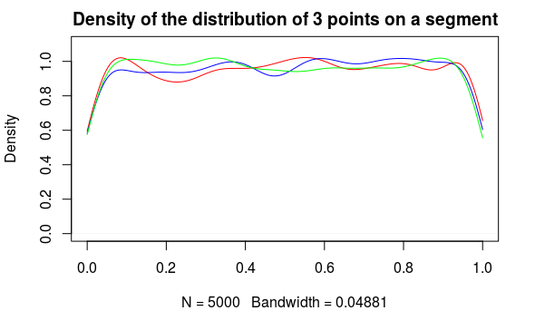

```r
lines(density(temp$X3, from = 0, to = 1), col = 'green')
```

It also works for an arbitrary `n`, `size`, `range`, and `d`.

```r
temp <- sampler_gibbs(size = 10, n = 5, range = c(-2, 3), d = 0.5)
print(temp)
```

|  | X1 | X2 | X3 | X4 | X5 |
| --- | --- | --- | --- | --- | --- |
| 1 | 0.4561952 | 1.10309023 | -1.2233125 | 1.9510890 | 2.9428081 |
| 2 | 2.5506734 | -0.49447516 | 0.1707350 | -0.9946044 | -1.9156851 |
| 3 | 2.5173699 | -1.78990347 | 0.9683609 | 1.8271414 | 0.3602413 |
| 4 | 0.7577661 | 2.09463217 | -0.5132502 | 0.2231177 | 1.3499582 |
| 5 | -1.1445799 | -0.36956075 | 0.2429277 | 0.8028998 | 2.2220922 |
| 6 | -1.2087548 | 0.09283876 | -1.8679531 | 2.4361411 | -0.6102147 |
| 7 | -1.4224531 | -0.84035790 | 0.4997349 | -0.2867281 | 2.3690384 |
| 8 | 0.5445656 | -0.56245309 | 1.1918250 | 2.9215731 | -1.7046982 |
| 9 | 2.8986073 | -0.88923143 | 0.2582064 | 2.0526974 | -1.7096475 |
| 10 | 2.3952083 | 0.48878314 | -1.2424438 | -0.3414637 | 1.5187625 |

### 5 numbers: their sum and their product (Ross, Exercise 10i)

```r
# returns the ratio of the number when the product of all x_i is higher than 120
Gibbs_prob <- function(iter = 1000) {
    # let's choose an arbitrary set of numbers that sum up to 15
    numbers <- seq(5)
    # start counter
    counter <- 0

    # repeat the following 'iter'times
    for (i in seq(iter)) {

        # choose indices of elements that will be replaced
        idx1 <- as.integer(5 * runif(1)) + 1
        idx2 <- as.integer(5 * runif(1)) + 1

        # make sure that indices are not the same
        while (idx1 == idx2) {
            idx2 <- as.integer(5 * runif(1)) + 1
        }

        # according to the prove 260 page we may calculate the rate as follows
        rate <- abs(1/idx1 - 1/idx2)
        # plug calculated rate into distribution
        x <- rexp(n = 1, rate)
        # replace the 'idx1' elem
        numbers[idx1] <- x
        # in order to keep the sum equal to 15 subtract all element excep for one
        numbers[idx2] <- 15 - sum(numbers[-idx2])

        # if the product of all numbers is 120 increase the counter
        if (prod(numbers) > 120) {
            counter <- counter + 1
        }
    }
    return(counter / iter)
}
```

```r
print(Gibbs_prob(iter = 10))
```

```
[1] 0.5
```

```r
print(Gibbs_prob(iter = 100))
```

```
[1] 0.22
```

```r
print(Gibbs_prob(iter = 1000))
```

```
[1] 0.13
```

```r
print(Gibbs_prob(iter = 10000))
```

```
[1] 0.1843
```

```r
print(Gibbs_prob(iter = 100000))
```

```
[1] 0.18292
```

```r
print(Gibbs_prob(iter = 1000000))
```

```
[1] 0.183377
```